# SPATIAL DATA & GIS OPERATIONS IN R

WEEK 4 IN-CLASS LAB

Author

Tess Vu

Published

September 29, 2025

# SPATIAL OPERATIONS WITH PENNSYLVANIA DATA

## Setup

```r
library(sf)
library(tidyverse)
library(tigris)
library(tidycensus)
library(scales)
library(patchwork)
library(here)
# Set Census API key
census_api_key("3aaee31789e10b674a531e9f236c35d5394b19ed")

# Load the data (same as lecture)
pa_counties <- st_read("data/Pennsylvania_County_Boundaries.shp")
districts <- st_read("data/districts.geojson")
hospitals <- st_read("data/hospitals.geojson")
census_tracts <- tracts(state = "PA", cb = TRUE)
metro_areas <- core_based_statistical_areas(cb = TRUE)
# Standardize CRS
hospitals <- st_transform(hospitals, st_crs(pa_counties))
census_tracts <- st_transform(census_tracts, st_crs(pa_counties))
metro_areas <- st_transform(metro_areas, st_crs(pa_counties))
districts <- st_transform(districts, st_crs(census_tracts))
```

## Exercise 1: Find Your County’s Neighbors (10 minutes)

**Goal:** Practice spatial filtering with different predicates

### 1.1 Pick a Pennsylvania County

**Your Task:** Choose any PA county and find all counties that border it.

```r
# Step 1: Look at available county names
unique(pa_counties$COUNTY_NAM)
```

```
 [1] "MONTGOMERY"     "BRADFORD"       "BUCKS"          "TIOGA"
 [5] "UNION"          "VENANGO"        "WASHINGTON"     "WAYNE"
 [9] "MCKEAN"         "MERCER"         "MIFFLIN"        "MONTOUR"
[13] "NORTHAMPTON"    "NORTHUMBERLAND" "PERRY"          "PIKE"
[17] "POTTER"         "SCHUYLKILL"     "SNYDER"         "SOMERSET"
[21] "SULLIVAN"       "LEBANON"        "BUTLER"         "CAMBRIA"
[25] "CAMERON"        "CARBON"         "CENTRE"         "CLARION"
[29] "CLEARFIELD"     "CLINTON"        "COLUMBIA"       "CRAWFORD"
[33] "CUMBERLAND"     "DAUPHIN"        "INDIANA"        "JEFFERSON"
[37] "JUNIATA"        "LANCASTER"      "WESTMORELAND"   "WYOMING"
[41] "YORK"           "PHILADELPHIA"   "LEHIGH"         "LUZERNE"
[45] "LYCOMING"       "LAWRENCE"       "DELAWARE"       "ELK"
[49] "ERIE"           "FAYETTE"        "FOREST"         "FRANKLIN"
[53] "FULTON"         "GREENE"         "HUNTINGDON"     "ADAMS"
[57] "ALLEGHENY"      "ARMSTRONG"      "BEAVER"         "BEDFORD"
[61] "BLAIR"          "SUSQUEHANNA"    "WARREN"         "BERKS"
[65] "CHESTER"        "MONROE"         "LACKAWANNA"
```

```r
# Step 2: Pick one county (change this to your choice!)
my_county <- pa_counties %>%
  filter(COUNTY_NAM == "BLAIR") # Change "CENTRE" to your county

# Step 3: Find neighbors using st_touches
my_neighbors <- pa_counties %>%
  st_filter(my_county, .predicate = st_touches)

# Step 4: How many neighbors does your county have?
cat("Number of neighboring counties:", nrow(my_neighbors), "\n")
```

```
Number of neighboring counties: 5
```

```r
print("Neighbor names:")
```

```
[1] "Neighbor names:"
```

```r
print(my_neighbors$COUNTY_NAM)
```

```
[1] "CAMBRIA"    "CENTRE"     "CLEARFIELD" "HUNTINGDON" "BEDFORD"
```

### 1.2 Map Your Results

**Your Task:** Create a map showing your county and its neighbors in different colors.

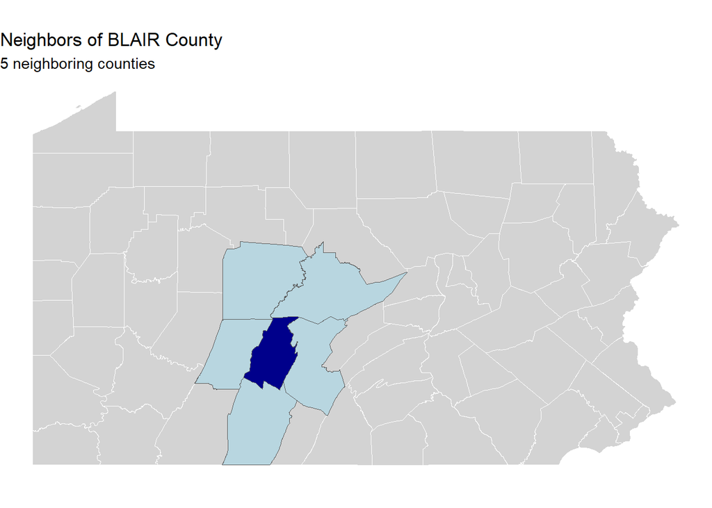

```r
# Create the map
ggplot() +
  geom_sf(data = pa_counties, fill = "lightgray", color = "white") +
  geom_sf(data = my_neighbors, fill = "lightblue", alpha = 0.7) +
  geom_sf(data = my_county, fill = "darkblue") +
  labs(
    title = paste("Neighbors of", my_county$COUNTY_NAM[1], "County"),
    subtitle = paste(nrow(my_neighbors), "neighboring counties")
  ) +
  theme_void()
```

### 1.3 Challenge: Compare with st_intersects

**Your Task:** What happens if you use `st_intersects` instead of `st_touches`? Why is the count different?

```r
# Use st_intersects
intersecting_counties <- pa_counties %>%
  st_filter(my_county, .predicate = st_intersects)

cat("With st_touches:", nrow(my_neighbors), "counties\n")
```

```
With st_touches: 5 counties
```

```r
cat("With st_intersects:", nrow(intersecting_counties), "counties\n")
```

```
With st_intersects: 6 counties
```

```r
cat("Difference:", nrow(intersecting_counties) - nrow(my_neighbors), "\n")
```

```
Difference: 1
```

**Question:** Why is there a difference of 1? What does this tell you about the difference between `st_touches` and `st_intersects`?

The difference of 1 is likely because st_intersects includes the county chosen as opposed to st_touches, which excludes the chosen county Blair.

## Exercise 2: Hospital Service Areas (15 minutes)

**Goal:** Practice buffering and measuring accessibility

### 2.1 Create Hospital Service Areas

**Your Task:** Create 15-mile (24140 meter) service areas around all hospitals in your county.

```r
# Step 1: Filter hospitals in your county
# First do a spatial join to assign counties to hospitals
hospitals_with_county <- hospitals %>%
  st_join(pa_counties %>% select(COUNTY_NAM))

# Filter for your county's hospitals
my_county_hospitals <- hospitals_with_county %>%
  filter(COUNTY_NAM == "BLAIR") # Change to match your county

cat("Number of hospitals in county:", nrow(my_county_hospitals), "\n")
```

```
Number of hospitals in county: 4
```

```r
# Step 2: Project to accurate CRS for buffering
my_county_hospitals_proj <- my_county_hospitals %>%
  st_transform(3365)  # Pennsylvania State Plane South

# Step 3: Create 15-mile buffers (24140 meters = 15 miles)
hospital_service_areas <- my_county_hospitals_proj %>%
  st_buffer(dist = 79200)  # 15 miles in feet for PA State Plane

# Step 4: Transform back for mapping
hospital_service_areas <- st_transform(hospital_service_areas, st_crs(pa_counties))
```

### 2.2 Map Service Coverage

**Your Task:** Create a map showing hospitals and their service areas.

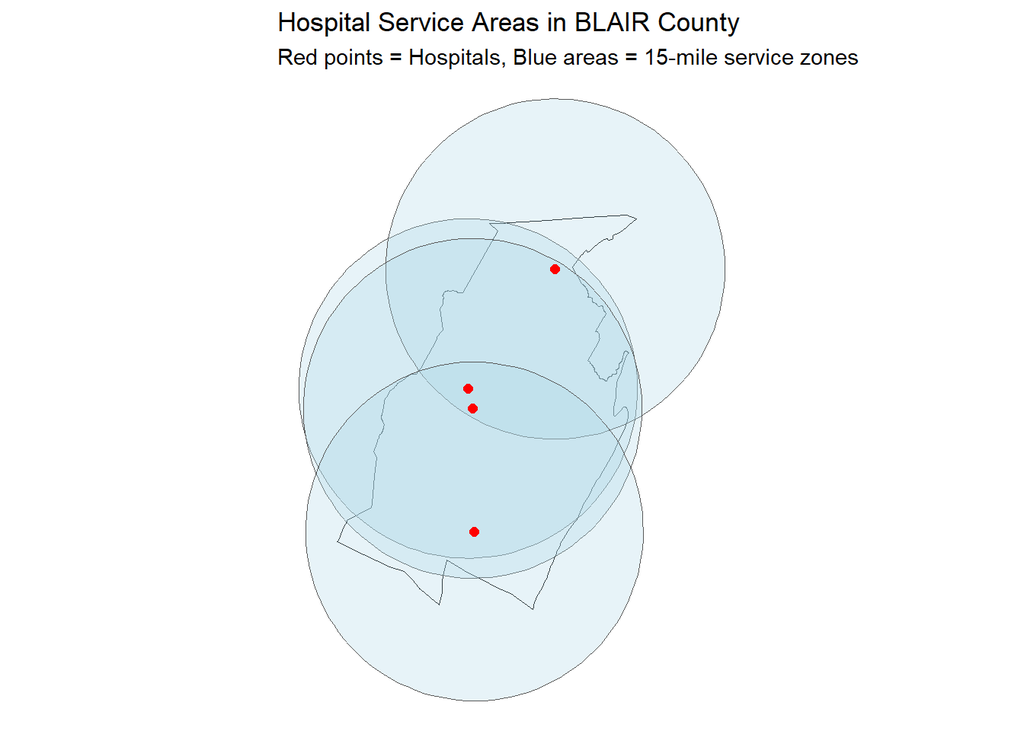

```r
ggplot() +
  geom_sf(data = my_county, fill = "white", color = "black") +
  geom_sf(data = hospital_service_areas, fill = "lightblue", alpha = 0.3) +
  geom_sf(data = my_county_hospitals, color = "red", size = 2) +
  labs(
    title = paste("Hospital Service Areas in", my_county$COUNTY_NAM[1], "County"),
    subtitle = "Red points = Hospitals, Blue areas = 15-mile service zones"
  ) +
  theme_void()
```

### 2.3 Calculate Coverage

**Your Task:** What percentage of your county is within 15 miles of a hospital?

```r
# Union all service areas into one polygon
combined_service_area <- hospital_service_areas %>%
  st_union()

# Calculate areas (need to be in projected CRS)
my_county_proj <- st_transform(my_county, 3365)
combined_service_proj <- st_transform(combined_service_area, 3365)

# Find intersection
coverage_area <- st_intersection(my_county_proj, combined_service_proj)

# Calculate percentages
county_area <- as.numeric(st_area(my_county_proj))
covered_area <- as.numeric(st_area(coverage_area))
coverage_pct <- (covered_area / county_area) * 100

cat("County area:", round(county_area / 1e6, 1), "sq km\n")
```

```
County area: 14690.2 sq km
```

```r
cat("Covered area:", round(covered_area / 1e6, 1), "sq km\n")
```

```
Covered area: 14690.2 sq km
```

```r
cat("Coverage:", round(coverage_pct, 1), "%\n")
```

```
Coverage: 100 %
```

**Question:** Is your county well-served by hospitals? What areas might be underserved?

The county seems to be well-served, but looking at the coverage of Blair’s surrounding counties could be a good further step because this doesn’t account for boundary spillover; people generally don’t confine the services they seek strictly within county or state boundaries.

## Exercise 3: Congressional District Analysis (15 minutes)

**Goal:** Practice spatial joins and aggregation

### 4.1 Join Districts to Counties

**Your Task:** Figure out which congressional districts overlap with each county.

```r
# Spatial join: districts to counties
districts_by_county <- districts %>%
  st_join(pa_counties %>% select(COUNTY_NAM)) %>%
  st_drop_geometry() %>%
  group_by(COUNTY_NAM) %>%
  summarize(
    n_districts = n_distinct(OBJECTID),
    district_ids = paste(unique(MSLINK), collapse = ", ")
  ) %>%
  arrange(desc(n_districts))

# Which counties have the most districts?
head(districts_by_county, 10)
```

```
# A tibble: 10 × 3
   COUNTY_NAM   n_districts district_ids
   <chr>              <int> <chr>
 1 MONTGOMERY             7 19, 2, 14, 20, 4, 15, 21
 2 BERKS                  6 8, 19, 2, 14, 4, 5
 3 ALLEGHENY              5 11, 12, 17, 1, 7
 4 PHILADELPHIA           5 19, 14, 20, 15, 21
 5 WESTMORELAND           5 11, 12, 17, 3, 7
 6 BUCKS                  4 19, 2, 14, 20
 7 CHESTER                4 14, 4, 5, 15
 8 DAUPHIN                4 8, 3, 5, 6
 9 JUNIATA                4 8, 12, 3, 6
10 LANCASTER              4 8, 4, 5, 6
```

### 4.2 Calculate District Statistics

**Your Task:** Get demographic data for census tracts and aggregate to districts.

```r
# Get tract-level demographics
tract_demographics <- get_acs(
  geography = "tract",
  variables = c(
    total_pop = "B01003_001",
    median_income = "B19013_001",
    white_pop = "B03002_003",
    black_pop = "B03002_004",
    hispanic_pop = "B03002_012"
  ),
  state = "PA",
  year = 2022,
  output = "wide"
)

# Join to tract boundaries
tracts_with_data <- census_tracts %>%
  left_join(tract_demographics, by = "GEOID")

# Spatial join to districts and aggregate
district_demographics <- tracts_with_data %>%
  st_join(districts) %>%
  st_drop_geometry() %>%
  group_by(OBJECTID, MSLINK) %>%
  summarize(
    total_population = sum(total_popE, na.rm = TRUE),
    median_income = weighted.mean(median_incomeE, total_popE, na.rm = TRUE),
    pct_white = sum(white_popE, na.rm = TRUE) / sum(total_popE, na.rm = TRUE) * 100,
    pct_black = sum(black_popE, na.rm = TRUE) / sum(total_popE, na.rm = TRUE) * 100,
    pct_hispanic = sum(hispanic_popE, na.rm = TRUE) / sum(total_popE, na.rm = TRUE) * 100,
    n_tracts = n()
  ) %>%
  arrange(desc(total_population))

# Show results
head(district_demographics, 10)
```

```
# A tibble: 10 × 8
# Groups:   OBJECTID [10]
   OBJECTID MSLINK total_population median_income pct_white pct_black
      <int>  <int>            <dbl>         <dbl>     <dbl>     <dbl>
 1      113     14          1229246       107602.      72.0     11.0
 2      108     11          1010001        76612.      76.6     13.4
 3      120      7          1006212        88796.      83.3      8.15
 4      107      8           993966        70241.      88.7      2.24
 5      117      3           986114        69017.      91.0      2.25
 6      109     12           979419        63952.      92.2      1.81
 7      118      4           974715       111250.      73.0      5.00
 8      114     17           972225        71139.      91.8      2.75
 9      110     19           932212       113798.      80.7      3.79
10      123      6           927718        80080.      75.6      8.65
# ℹ 2 more variables: pct_hispanic <dbl>, n_tracts <int>
```

### 4.3 Map District Demographics

**Your Task:** Create a choropleth map of median income by congressional district.

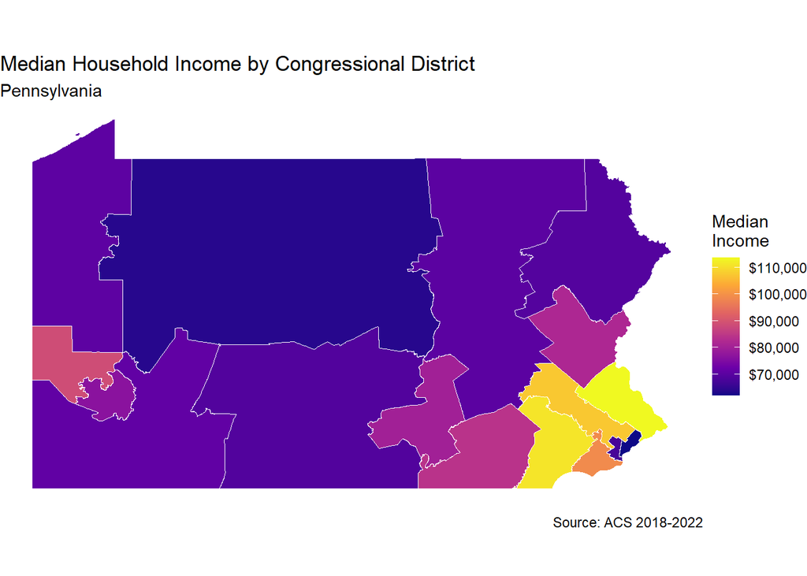

```r
# Join demographics back to district boundaries
districts_with_demographics <- districts %>%
  left_join(district_demographics, by = "OBJECTID")

# Create the map
ggplot(districts_with_demographics) +
  geom_sf(aes(fill = median_income), color = "white", size = 0.5) +
  scale_fill_viridis_c(
    name = "Median\nIncome",
    labels = dollar,
    option = "plasma"
  ) +
  labs(
    title = "Median Household Income by Congressional District",
    subtitle = "Pennsylvania",
    caption = "Source: ACS 2018-2022"
  ) +
  theme_void()
```

### 4.4 Challenge: Find Diverse Districts

**Your Task:** Which districts are the most racially diverse?

```r
# Calculate diversity index (simple version: higher = more diverse)
# A perfectly even distribution would be ~33% each for 3 groups
district_demographics <- district_demographics %>%
  mutate(
    diversity_score = 100 - abs(pct_white - 33.3) - abs(pct_black - 33.3) - abs(pct_hispanic - 33.3)
  ) %>%
  arrange(desc(diversity_score))

# Most diverse districts
head(district_demographics %>% select(MSLINK, pct_white, pct_black, pct_hispanic, diversity_score), 5)
```

```
# A tibble: 5 × 6
# Groups:   OBJECTID [5]
  OBJECTID MSLINK pct_white pct_black pct_hispanic diversity_score
     <int>  <int>     <dbl>     <dbl>        <dbl>           <dbl>
1      115     20      37.9     25.4         23.7             77.8
2      122     21      33.5     49.7          5.73            55.9
3      121     15      58.8     24.4          5.77            38.1
4      111      2      71.2      4.88        18.3             18.7
5      113     14      72.0     11.0          7.09            12.8
```

```r
# Least diverse districts
tail(district_demographics %>% select(MSLINK, pct_white, pct_black, pct_hispanic, diversity_score), 5)
```

```
# A tibble: 5 × 6
# Groups:   OBJECTID [5]
  OBJECTID MSLINK pct_white pct_black pct_hispanic diversity_score
     <int>  <int>     <dbl>     <dbl>        <dbl>           <dbl>
1      107      8      88.7      2.24         5.73           -14.1
2      116      1      89.3      3.66         2.53           -16.4
3      117      3      91.0      2.25         3.24           -18.8
4      114     17      91.8      2.75         1.49           -20.9
5      109     12      92.2      1.81         2.09           -21.6
```

## Exercise 5: Projection Effects (10 minutes)

**Goal:** Understand how CRS affects calculations

### 5.1 Calculate Areas in Different Projections

**Your Task:** Calculate county areas using different coordinate systems and compare.

```r
# Calculate areas in different CRS
area_comparison <- pa_counties %>%
  # Geographic (WGS84) - WRONG for areas!
  st_transform(4326) %>%
  mutate(area_geographic = as.numeric(st_area(.))) %>%
  # PA State Plane South - Good for PA
  st_transform(3365) %>%
  mutate(area_state_plane = as.numeric(st_area(.))) %>%
  # Albers Equal Area - Good for areas
  st_transform(5070) %>%
  mutate(area_albers = as.numeric(st_area(.))) %>%
  st_drop_geometry() %>%
  select(COUNTY_NAM, starts_with("area_")) %>%
  mutate(
    # Calculate errors compared to Albers (most accurate for area)
    error_geographic_pct = abs(area_geographic - area_albers) / area_albers * 100,
    error_state_plane_pct = abs(area_state_plane - area_albers) / area_state_plane * 100
  )

# Show counties with biggest errors
area_comparison %>%
  arrange(desc(error_geographic_pct)) %>%
  select(COUNTY_NAM, error_geographic_pct, error_state_plane_pct) %>%
  head(10)
```

```
    COUNTY_NAM error_geographic_pct error_state_plane_pct
1         ERIE            0.1520567              90.71567
2  SUSQUEHANNA            0.1480129              90.71426
3       MCKEAN            0.1479719              90.71414
4       WARREN            0.1478826              90.71421
5     BRADFORD            0.1473177              90.71402
6        TIOGA            0.1469541              90.71390
7       POTTER            0.1463317              90.71371
8     CRAWFORD            0.1447572              90.71326
9        WAYNE            0.1440222              90.71306
10     WYOMING            0.1409741              90.71215
```

### 5.2 Visualize the Error

**Your Task:** Map which counties have the biggest area calculation errors.

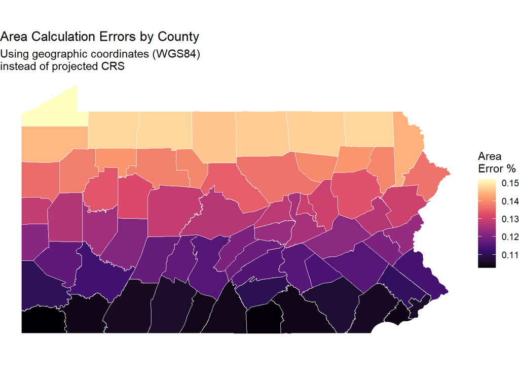

```r
# Join error data back to counties
counties_with_errors <- pa_counties %>%
  left_join(
    area_comparison %>% select(COUNTY_NAM, error_geographic_pct),
    by = "COUNTY_NAM"
  )

# Map the error
ggplot(counties_with_errors) +
  geom_sf(aes(fill = error_geographic_pct), color = "white") +
  scale_fill_viridis_c(
    name = "Area\nError %",
    option = "magma"
  ) +
  labs(
    title = "Area Calculation Errors by County",
    subtitle = "Using geographic coordinates (WGS84)\ninstead of projected CRS"
  ) +
  theme_void()
```

**Question:** Which counties have the largest errors? Why might this be?

Counties toward the north of Pennsylvania have the largest errors, likely because the CRS was a 3-dimensional GCS (WGS84) when the area calculations were done. Geographic coordinate systems have more warping at the poles when displayed on a 2-dimensional surface when it comes to area as a cost to preserve other geometric factors.

## Bonus Challenge: Combined Analysis (If Time Permits)

**Goal:** Combine multiple operations for a complex policy question

### Research Question

**Which Pennsylvania counties have the highest proportion of vulnerable populations (elderly + low-income) living far from hospitals?**

**Your Task:** Combine what you’ve learned to identify vulnerable, underserved communities.

**Steps:** 1. Get demographic (elderly and income) data for census tracts 2. Identify vulnerable tracts (low income AND high elderly population) 3. Calculate distance to nearest hospital 4. Check which ones are more than 15 miles from a hospital 5. Aggregate to county level 6. Create comprehensive map 7. Create a summary table

## Reflection Questions

After completing these exercises, reflect on:

1. **When did you need to transform CRS?** Why was this necessary?
2. **What’s the difference between `st_filter()` and `st_intersection()`?** When would you use each?
3. **How does the choice of predicate (st_touches, st_intersects, st_within) change your results?**

## Summary of Key Functions Used

| Function | Purpose | Example Use |
| --- | --- | --- |
| `st_filter()` | Select features by spatial relationship | Find neighboring counties |
| `st_buffer()` | Create zones around features | Hospital service areas |
| `st_intersects()` | Test spatial overlap | Check access to services |
| `st_disjoint()` | Test spatial separation | Find rural areas |
| `st_join()` | Join by location | Add county info to tracts |
| `st_union()` | Combine geometries | Merge overlapping buffers |
| `st_intersection()` | Clip geometries | Calculate overlap areas |
| `st_transform()` | Change CRS | Accurate distance/area calculations |
| `st_area()` | Calculate areas | County sizes, coverage |
| `st_distance()` | Calculate distances | Distance to facilities |

**Important Reminder:** Always *check* and standardize CRS when working with spatial data from multiple sources!